# Comparison of scMC against other methods on a mouse skin dermis dataset

Lihua Zhang

27/12/20

Here we showcase scMC’s superior performance in detecting context-shared and -specific biological signals by applying it to a mouse skin scRNA-seq dataset and comparing it with other methods, including [Seurat](https://satijalab.org/seurat/v3.2/immune_alignment.html), [Harmony](http://htmlpreview.github.io/?https://github.com/immunogenomics/harmony/blob/master/docs/SeuratV3.html) and [LIGER](https://htmlpreview.github.io/?https://github.com/satijalab/seurat.wrappers/blob/master/docs/liger.html). This dataset contains cells from control and Hedgehog (Hh) activation conditions during skin wound healing.

# Import data

We load a list of preprocessed Seurat objects (one per dataset). The column `clusters.final` in the meta.data represents the annotated cell labels, which are determined based on the cell clusters identified using scMC by examining the expression patterns of known markers.

```r
load("/Users/suoqinjin/Documents/scMC-master/tutorial/SeuratObjectList_benchmark_dermis.RData")
```

# Perform an integrated analysis using scMC

```r
library(scMC)
library(Seurat)

# Run scMC Seurat wrapper
combined <- RunscMC(object.list)
```

```
#> Performing PCA in Dataset  1
#> Building SNN on the PCA space in Dataset  1
#> Performing PCA in Dataset  2
#> Building SNN on the PCA space in Dataset  2
#> Identifying cell clusters in Dataset 1
#> Peforming hierarchical clustering on the computed consensus matrix
#> The initial guessed number of clusters is 17
#> Identifying cell clusters in Dataset 2
#> Peforming hierarchical clustering on the computed consensus matrix
#> The initial guessed number of clusters is 16
#> Identifying marker genes of cell clusters in Dataset 1
#> Identifying marker genes of cell clusters in Dataset 2
```

```r
nPC = 40
combined <- FindNeighbors(combined, reduction = "scMC", dims = 1:nPC)
combined <- FindClusters(combined, algorithm = 4, resolution = 0.05)
combined <- BuildClusterTree(combined, reorder = T, reorder.numeric = T, verbose = F)
combined <- RunUMAP(combined, reduction='scMC', dims = 1:nPC)
combined$scMC.clusters <- Idents(combined)
combined.scMC <- combined
```

# Perform an integrated analysis using Seurat

```r
library(Seurat)

# Run Seurat
anchors <- FindIntegrationAnchors(object.list, dims = 1:nPC)
combined <- IntegrateData(anchorset = anchors, dims = 1:nPC)

DefaultAssay(combined) <- "integrated"
combined <- ScaleData(combined, verbose = FALSE)
combined <- RunPCA(combined, npcs = nPC, verbose = FALSE)
combined <- RunUMAP(combined, reduction = "pca", dims = 1:nPC)
combined <- FindNeighbors(combined, reduction = "pca", dims = 1:nPC)
combined <- FindClusters(combined, resolution = 0.07)
```

```
#> Modularity Optimizer version 1.3.0 by Ludo Waltman and Nees Jan van Eck
#>
#> Number of nodes: 4639
#> Number of edges: 160443
#>
#> Running Louvain algorithm...
#> Maximum modularity in 10 random starts: 0.9756
#> Number of communities: 6
#> Elapsed time: 0 seconds
```

```r
combined$Seurat.clusters <- Idents(combined)
combined.seurat <- combined
```

# Perform an integrated analysis using Harmony

```r
library(harmony)
library(dplyr)

# Run Harmony
combined <- merge(x = object.list[[1]],y = object.list[2:length(x = object.list)])
combined <- combined %>%
  NormalizeData(verbose = FALSE) %>%
  FindVariableFeatures(selection.method = "vst") %>%
  ScaleData(verbose = FALSE) %>%
  RunPCA(pc.genes = combined@var.genes, npcs = 40, verbose = FALSE)
combined <- combined %>%
  RunHarmony("sample.name", plot_convergence = F)

combined <- combined %>%
  RunUMAP(reduction = "harmony", dims = 1:nPC) %>%
  FindNeighbors(reduction = "harmony", dims = 1:nPC) %>%
  FindClusters(resolution = 0.06) %>%
  identity()
```

```
#> Modularity Optimizer version 1.3.0 by Ludo Waltman and Nees Jan van Eck
#>
#> Number of nodes: 4639
#> Number of edges: 160911
#>
#> Running Louvain algorithm...
#> Maximum modularity in 10 random starts: 0.9786
#> Number of communities: 6
#> Elapsed time: 0 seconds
```

```r
combined$Harmony.clusters <- Idents(combined)
combined.harmony <- combined
```

# Perform an integrated analysis using LIGER

```r
library(liger)
library(SeuratWrappers)

# Run LIGER
combined <- merge(x = object.list[[1]],y = object.list[2:length(x = object.list)])
combined <- NormalizeData(combined)
combined <- FindVariableFeatures(combined)
combined <- ScaleData(combined, split.by = "sample.name", do.center = FALSE)

combined <- RunOptimizeALS(combined, k = 40, split.by = "sample.name", verbose = FALSE)
combined <- RunQuantileNorm(combined, split.by = "sample.name")
combined <- FindNeighbors(combined, reduction = "iNMF", dims = 1:nPC)
combined <- FindClusters(combined, resolution = 0.06)
combined <- RunUMAP(combined, dims = 1:ncol(combined[["iNMF"]]), reduction = "iNMF")
combined$LIGER.clusters <- Idents(combined)
combined.liger <- combined
```

# Visualization and comparison

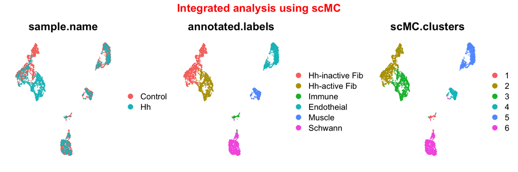

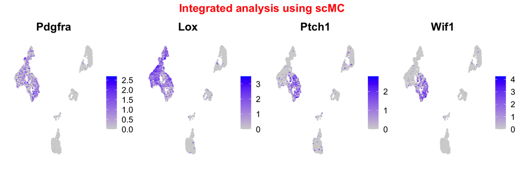

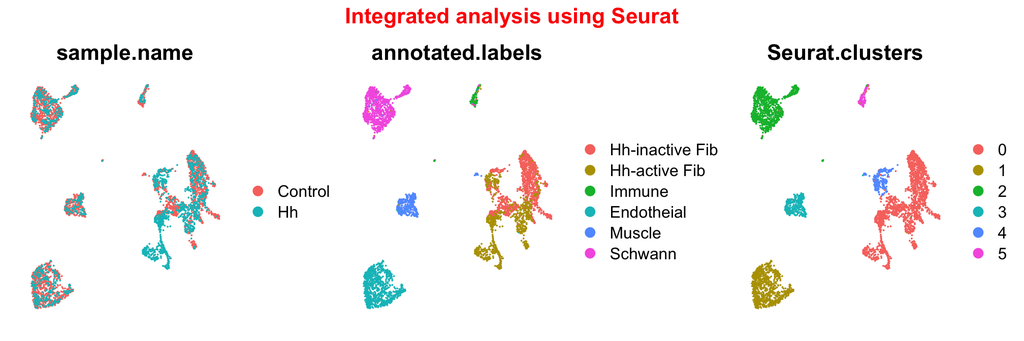

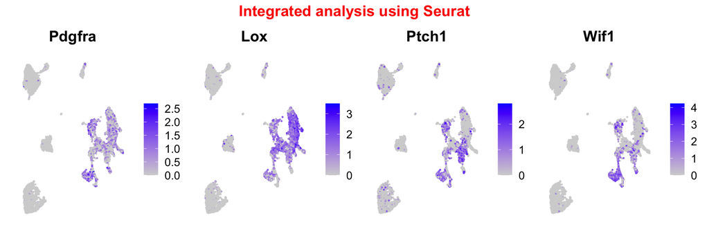

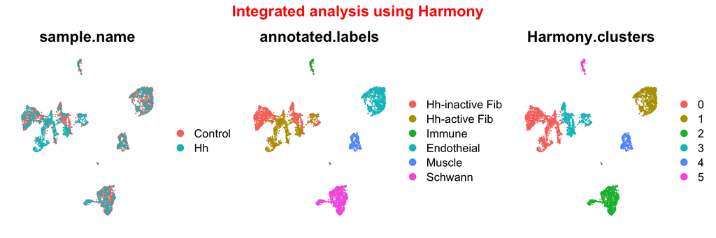

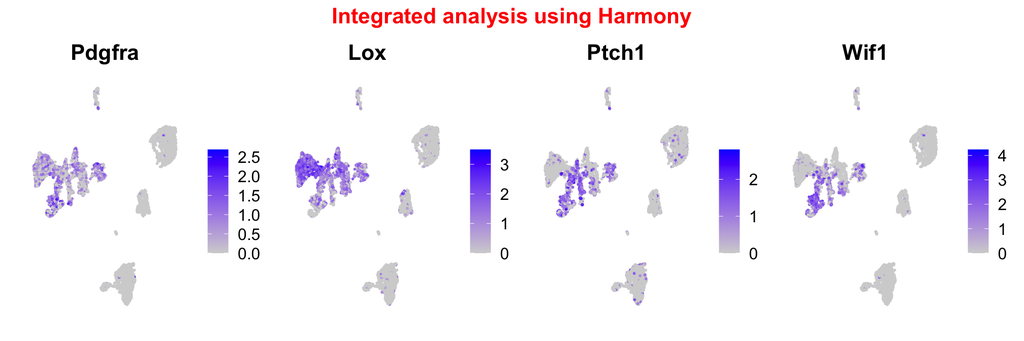

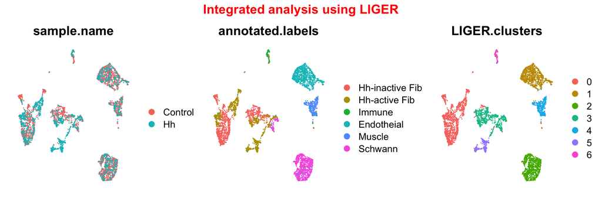

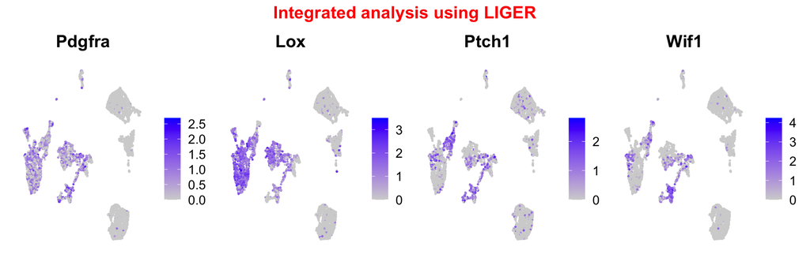

```r
library(patchwork)
library(ggplot2)

combined.all <- list(combined.scMC, combined.seurat, combined.harmony, combined.liger)
methods <- c("scMC", "Seurat", "Harmony", "LIGER")
for (i in 1:length(combined.all)) {
  combined <- combined.all[[i]]
  combined$sample.name[combined$sample.name == "Hh activation"] <- "Hh"
  new.order <- c("Hh-inactive Fib", "Hh-active Fib","Immune","Endotheial", "Muscle", "Schwann")
  combined$annotated.labels <- factor(combined$clusters.final, levels = new.order)
  DefaultAssay(combined) <- "RNA"
  # Visualize cells onto the low-dimensional space
gg <- DimPlot(combined, group.by = c("sample.name", "annotated.labels",paste0(methods[i], ".clusters")),pt.size = 0.0001, ncol = 3)  +
  plot_annotation(paste0('Integrated analysis using ', methods[i]), theme = theme(plot.title = element_text(size = 16, hjust = 0.5, face = "bold", color="red"))) & NoAxes()
print(gg)

# Feature plot of fibroblast marker genes
# Overlay the expression levels of fibroblasts pan-markers (Pdgfra and Lox) and Hh-active fibroblast markers (Ptch1 and Wif1) onto the UMAP space
features = c('Pdgfra','Lox','Ptch1','Wif1')
gg <- FeaturePlot(combined, features = features, ncol = 4) +
  plot_annotation(paste0('Integrated analysis using ', methods[i]), theme = theme(plot.title = element_text(size = 16, hjust = 0.5, face = "bold", color="red"))) & NoAxes()
print(gg)
}
```

As shown in the integrated UMAP space above, scMC is able to reveal one specific fibroblast subpopulation (marked by high Ptch1+ cells) upon Hedgehog activation compared to the control condition, while other methods fail to detect such an important change during mouse skin wound healing. scMC uses Leiden algorithm for clustering by default. The performance of Seurat, Harmony and LIGER retains similar when using the Leiden algorithm for clustering compared to the Louvain algorithm, on this dataset.